# Lab 4 - Exploratory Data Analysis

# EPA 1 - Penguins

## Data

The data we are going to use for this Exploratory Data Analysis is **Palmer Penguins**. This data set comes from the `palmerpenguins` package in R.

### Description:

Size measurements, clutch observations, and blood isotope ratios for adult foraging Adélie, Chinstrap, and Gentoo penguins observed on islands in the Palmer Archipelago near Palmer Station, Antarctica. Data were collected and made available by Dr. Kristen Gorman and the Palmer Station Long Term Ecological Research (LTER) Program.

```r
# write code to display first 10 rows of the penguins dataset


head(penguins, n=10)
```

```
## # A tibble: 10 × 8
##    species island    bill_length_mm bill_depth_mm flipper_length_mm body_mass_g
##    <fct>   <fct>              <dbl>         <dbl>             <int>       <int>
##  1 Adelie  Torgersen           39.1          18.7               181        3750
##  2 Adelie  Torgersen           39.5          17.4               186        3800
##  3 Adelie  Torgersen           40.3          18                 195        3250
##  4 Adelie  Torgersen           NA            NA                  NA          NA
##  5 Adelie  Torgersen           36.7          19.3               193        3450
##  6 Adelie  Torgersen           39.3          20.6               190        3650
##  7 Adelie  Torgersen           38.9          17.8               181        3625
##  8 Adelie  Torgersen           39.2          19.6               195        4675
##  9 Adelie  Torgersen           34.1          18.1               193        3475
## 10 Adelie  Torgersen           42            20.2               190        4250
## # ℹ 2 more variables: sex <fct>, year <int>
```

```r
# showing a glimpse of the penguins dataset
# notice I do not have to specify the package since the palmerpenguins and dplyr packages are loaded above
glimpse(penguins)
```

```
## Rows: 344
## Columns: 8
## $ species           <fct> Adelie, Adelie, Adelie, Adelie, Adelie, Adelie, Adel…
## $ island            <fct> Torgersen, Torgersen, Torgersen, Torgersen, Torgerse…
## $ bill_length_mm    <dbl> 39.1, 39.5, 40.3, NA, 36.7, 39.3, 38.9, 39.2, 34.1, …
## $ bill_depth_mm     <dbl> 18.7, 17.4, 18.0, NA, 19.3, 20.6, 17.8, 19.6, 18.1, …
## $ flipper_length_mm <int> 181, 186, 195, NA, 193, 190, 181, 195, 193, 190, 186…
## $ body_mass_g       <int> 3750, 3800, 3250, NA, 3450, 3650, 3625, 4675, 3475, …
## $ sex               <fct> male, female, female, NA, female, male, female, male…
## $ year              <int> 2007, 2007, 2007, 2007, 2007, 2007, 2007, 2007, 2007…
```

### The number of observations in the **Palmer Penguins** dataset is:

```r
# Number of observations in penguins dataset
nrow(penguins)
```

```
## [1] 344
```

### The number of variables in the **Palmer Penguins** dataset is:

```r
# Number of variables in penguins dataset
ncol(penguins)
```

```
## [1] 8
```

### Variables

A list of the variables in the `penguins` dataset is provided below:

| Variables |
| --- |
| species |
| island |
| bill_length_mm |
| bill_depth_mm |
| flipper_length_mm |
| body_mass_g |
| sex |
| year |

The image below displays the type of each of these variables.

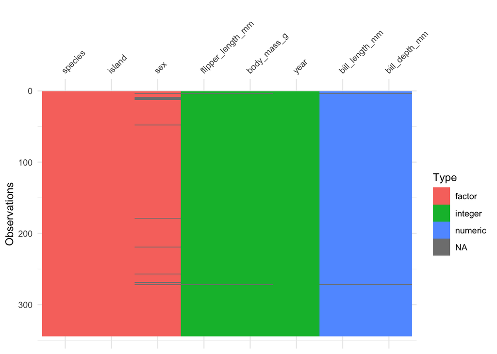

```r
# Create view of variable types from penguins dataset
library(visdat)
vis_dat(penguins)
```

### Descriptive Statistics

Using basic functions in R, we will explore some simple descriptive statistics for the 2 numeric variables (bill_length_mm and bil_depth_mm).

```r
# Descriptive Statistics for bill_length_mm
mean(x = penguins$bill_length_mm, na.rm = TRUE)
```

```
## [1] 43.92193
```

```r
# Descriptive Statistics for bill_depth_mm
mean(x = penguins$bill_depth_mm, na.rm = TRUE)
```

```
## [1] 17.15117
```

```r
sd(x = penguins$bill_depth_mm, na.rm = TRUE)
```

```
## [1] 1.974793
```

```r
min(x = penguins$bill_depth_mm, na.rm = TRUE)
```

```
## [1] 13.1
```

```r
max(x = penguins$bill_depth_mm, na.rm = TRUE)
```

```
## [1] 21.5
```

This is a way to obtain descriptive statistics all at once rather than one line of code at a time.

```r
# Code to display a table of descriptive statistics for the bill_lenghth_mm variable using the summarize function from dplyr package.
# Note an object stats_length is created that stores the table.

stats_length <- penguins %>%
  summarize(n= n(),
            x_bar = mean(bill_length_mm, na.rm = TRUE),
            s = sd(bill_length_mm, na.rm=TRUE),
            min = min(bill_length_mm, na.rm = TRUE),
            max(bill_length_mm, na.rm = TRUE))
stats_length
```

```
## # A tibble: 1 × 5
##       n x_bar     s   min `max(bill_length_mm, na.rm = TRUE)`
##   <int> <dbl> <dbl> <dbl>                               <dbl>
## 1   344  43.9  5.46  32.1                                59.6
```

```r
# Enter code to display a table of descriptive statistics for the bill_depth_mm variable
stat_depth <- penguins %>%
  summarize(n= n(),
            x_bar = mean(bill_depth_mm, na.rm = TRUE),
            s = sd(bill_depth_mm, na.rm=TRUE),
            min = min(bill_depth_mm, na.rm = TRUE),
            max(bill_depth_mm, na.rm = TRUE))
stat_depth
```

```
## # A tibble: 1 × 5
##       n x_bar     s   min `max(bill_depth_mm, na.rm = TRUE)`
##   <int> <dbl> <dbl> <dbl>                              <dbl>
## 1   344  17.2  1.97  13.1                               21.5
```